# Tugas-Pertemuan-2

## Library/Packages

```r
library("forecast")
```

```r
library("graphics")
library("TTR")
library("TSA")
```

## Impor Data

```r
library(rio) #install packages jika belum ada
data1 <- import("Data-Tugas-2.csv")

#via csv gunakan read.csv("namafile.csv")
#data1 <- read.csv("Data_1.csv")

# menampilkan 5 data pertama
head(data1)
```

```
##   Period    Price
## 1      1 41980.10
## 2      2 44080.65
## 3      3 43746.45
## 4      4 43292.66
## 5      5 44166.60
## 6      6 43725.98
```

## Eksplorasi Data

`View()` : menampilkan data dalam bentuk tabel, `str()` : menampilkan struktur data, `dim()` : menampilkan dimensi data

```r
View(data1)
str(data1)
```

```
## 'data.frame':    200 obs. of  2 variables:
##  $ Period: int  1 2 3 4 5 6 7 8 9 10 ...
##  $ Price : num  41980 44081 43746 43293 44167 ...
```

```r
dim(data1)
```

```
## [1] 200   2
```

Mengubah data agar terbaca sebagai data deret waktu dengan fungsi `ts()` .

```r
data1.ts <- ts(data1$Price)
```

Menampilkan ringkasan data

```r
summary(data1.ts)
```

```
##    Min. 1st Qu.  Median    Mean 3rd Qu.    Max.
##   39507   43771   62473   57166   67506   73084
```

Membuat plot data deret waktu

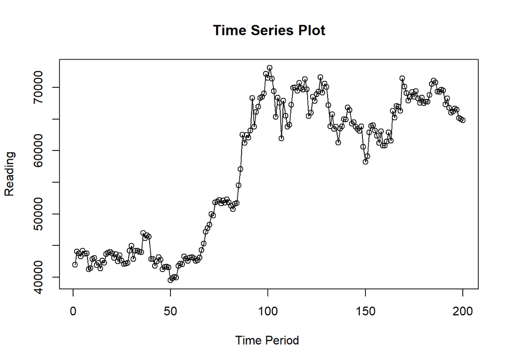

```r
ts.plot(data1.ts, xlab="Time Period ", ylab="Reading",
        main = "Time Series Plot")
points(data1.ts)
```

```r
#menyimpan plot
dev.copy(png, "plot_data1.png")
```

```r
dev.off()
```

## Moving Average

### Pembagian Data

Pembagian data latih dan data uji dilakukan dengan perbandingan 80% data latih dan 20% data uji.

```r
# hitung jumlah data
n <- nrow(data1)

# tentukan batas 80%
n_train <- floor(0.8 * n)

# bagi data
training_ma <- data1[1:n_train, ]
testing_ma  <- data1[(n_train+1):n, ]

# ubah ke time series
train_ma.ts <- ts(training_ma$Price)
test_ma.ts  <- ts(testing_ma$Price)
```

Eksplorasi data dilakukan pada keseluruhan data, data latih serta data uji menggunakan plot data deret waktu.

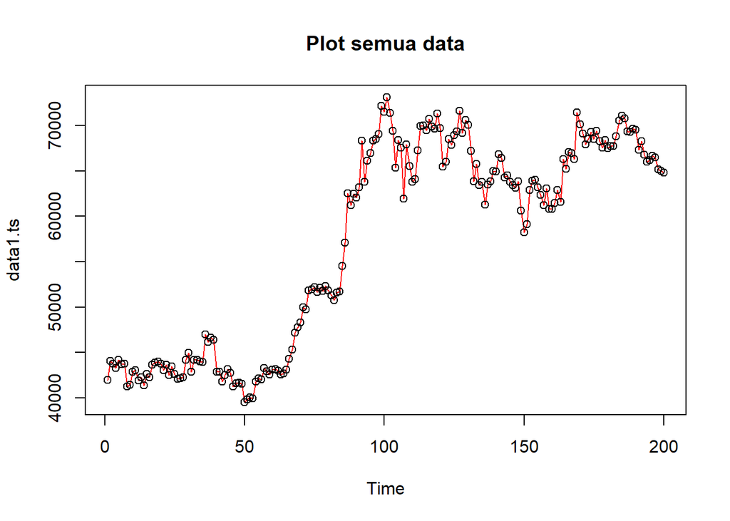

```r
#eksplorasi keseluruhan data
plot(data1.ts, col="red",main="Plot semua data")
points(data1.ts)
```

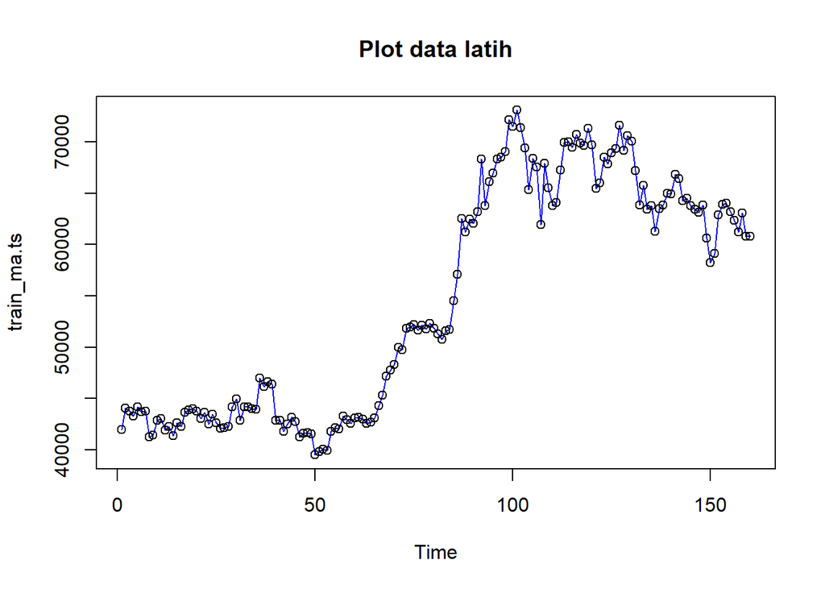

```r
#eksplorasi data latih
plot(train_ma.ts, col="blue",main="Plot data latih")
points(train_ma.ts)
```

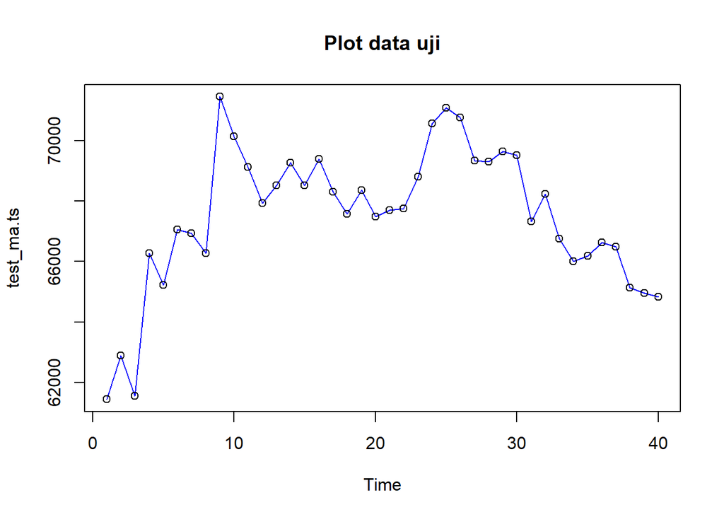

```r
#eksplorasi data uji
plot(test_ma.ts, col="blue",main="Plot data uji")
points(test_ma.ts)
```

Eksplorasi data juga dapat dilakukan menggunakan package `ggplot2` dengan terlebih dahulu memanggil library *package* `ggplot2`.

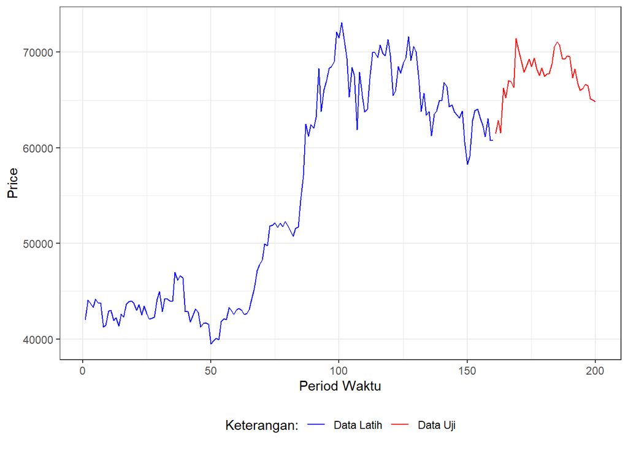

```r
library(ggplot2)
ggplot() +
  geom_line(data = training_ma, aes(x = Period, y = Price, col = "Data Latih")) +
  geom_line(data = testing_ma, aes(x = Period, y = Price, col = "Data Uji")) +
  labs(x = "Period Waktu", y = "Price", color = "Legend") +
   scale_colour_manual(name="Keterangan:", breaks = c("Data Latih", "Data Uji"),
                      values = c("blue", "red")) +
  theme_bw() + theme(legend.position = "bottom",
                     plot.caption = element_text(hjust=0.5, size=12))
```

### Single Moving Average (SMA)

Ide dasar dari Single Moving Average (SMA) adalah data suatu Period dipengaruhi oleh data Period sebelumnya. Metode pemulusan ini cocok digunakan untuk pola data stasioner atau konstan. Prinsip dasar metode pemulusan ini adalah data pemulusan pada Period ke-t merupakan rata rata dari m buah data pada Period ke-t hingga Period ke (t-m+1).

$$S_t = \frac{1}{m} \sum_{i=t-m+1}^{t} X_i$$
$$S_t = \frac{1}{m}
\sum_{i=t-m+1}^{t} X_i$$

Data pemulusan pada Period ke-t selanjutnya digunakan sebagai nilai peramalan pada Period ke t+1.

$$F_t = S_{t-1}, F_{n,h} =
S_n$$

Pemulusan menggunakan metode SMA dilakukan dengan fungsi `SMA()`. Dalam hal ini akan dilakukan pemulusan dengan parameter `m=4`.

```r
data.sma<-SMA(train_ma.ts, n=4)
data.sma
```

```
## Time Series:
## Start = 1
## End = 160
## Frequency = 1
##   [1]       NA       NA       NA 43274.96 43821.59 43732.92 43741.24 43229.03
##   [9] 42549.93 42341.12 42152.19 42323.67 42521.15 42139.63 42039.52 42124.71
##  [17] 42477.75 43103.87 43447.46 43814.71 43655.68 43591.68 43222.30 43148.13
##  [25] 43051.06 42672.63 42581.75 42287.34 42672.21 43386.85 43559.67 44038.35
##  [33] 44037.19 43795.00 44068.73 44766.37 45260.63 45920.28 46526.65 45497.32
##  [41] 44672.98 43465.10 42500.95 42576.39 42551.46 42417.91 42194.52 41822.18
##  [49] 41522.96 41084.29 40641.07 40243.94 39840.95 40418.33 40986.95 41476.58
##  [57] 42315.19 42599.13 42714.76 42974.81 42949.21 42959.12 42959.37 42855.09
##  [65] 42829.79 43161.29 43840.78 44962.92 46134.57 47128.49 48292.65 48941.46
##  [73] 49955.32 50866.48 51416.97 51897.11 51971.08 51931.22 51962.39 52006.44
##  [81] 51802.04 51540.24 51361.80 51335.32 52139.67 53728.03 56461.45 58827.74
##  [89] 60807.29 62043.41 62209.06 63992.07 64332.21 65351.45 66290.98 66283.40
##  [97] 67457.82 68186.06 69485.67 70280.97 71427.12 72021.32 71341.29 69799.75
## [105] 68626.53 67664.53 65791.78 66441.42 65716.61 64774.15 65311.51 65141.63
## [113] 66258.49 67810.76 69159.04 70036.74 70020.24 69934.61 70404.18 70143.48
## [121] 69032.02 68115.90 67409.69 66943.57 67805.85 68651.29 69431.92 69757.26
## [129] 70180.20 70354.72 69245.84 67916.46 66704.17 65045.57 64199.57 63563.37
## [137] 63006.88 63111.22 63406.86 64319.35 65150.58 65791.51 65612.12 65500.89
## [145] 64730.30 63983.27 63692.35 63532.20 62752.59 61461.30 60463.86 60226.03
## [153] 61039.69 62483.97 63493.60 63354.84 62678.96 62433.67 61841.37 61456.10
```

Data pemulusan pada Period ke-t selanjutnya digunakan sebagai nilai peramalan pada Period ke t+1 sehingga hasil peramalan 1 Period kedepan adalah sebagai berikut.

```r
data.ramal<-c(NA,data.sma)
data.ramal #forecast 1 Period ke depan
```

```
##   [1]       NA       NA       NA       NA 43274.96 43821.59 43732.92 43741.24
##   [9] 43229.03 42549.93 42341.12 42152.19 42323.67 42521.15 42139.63 42039.52
##  [17] 42124.71 42477.75 43103.87 43447.46 43814.71 43655.68 43591.68 43222.30
##  [25] 43148.13 43051.06 42672.63 42581.75 42287.34 42672.21 43386.85 43559.67
##  [33] 44038.35 44037.19 43795.00 44068.73 44766.37 45260.63 45920.28 46526.65
##  [41] 45497.32 44672.98 43465.10 42500.95 42576.39 42551.46 42417.91 42194.52
##  [49] 41822.18 41522.96 41084.29 40641.07 40243.94 39840.95 40418.33 40986.95
##  [57] 41476.58 42315.19 42599.13 42714.76 42974.81 42949.21 42959.12 42959.37
##  [65] 42855.09 42829.79 43161.29 43840.78 44962.92 46134.57 47128.49 48292.65
##  [73] 48941.46 49955.32 50866.48 51416.97 51897.11 51971.08 51931.22 51962.39
##  [81] 52006.44 51802.04 51540.24 51361.80 51335.32 52139.67 53728.03 56461.45
##  [89] 58827.74 60807.29 62043.41 62209.06 63992.07 64332.21 65351.45 66290.98
##  [97] 66283.40 67457.82 68186.06 69485.67 70280.97 71427.12 72021.32 71341.29
## [105] 69799.75 68626.53 67664.53 65791.78 66441.42 65716.61 64774.15 65311.51
## [113] 65141.63 66258.49 67810.76 69159.04 70036.74 70020.24 69934.61 70404.18
## [121] 70143.48 69032.02 68115.90 67409.69 66943.57 67805.85 68651.29 69431.92
## [129] 69757.26 70180.20 70354.72 69245.84 67916.46 66704.17 65045.57 64199.57
## [137] 63563.37 63006.88 63111.22 63406.86 64319.35 65150.58 65791.51 65612.12
## [145] 65500.89 64730.30 63983.27 63692.35 63532.20 62752.59 61461.30 60463.86
## [153] 60226.03 61039.69 62483.97 63493.60 63354.84 62678.96 62433.67 61841.37
## [161] 61456.10
```

```r
data.gab<-cbind(
  aktual=c(data1.ts),
  pemulusan=c(data.sma,rep(NA,40)),
  ramalan=c(data.ramal,rep(data.ramal[length(data.ramal)],39)))

data.gab #forecast 24 Period ke depan
```

```
##          aktual pemulusan  ramalan
##   [1,] 41980.10        NA       NA
##   [2,] 44080.65        NA       NA
##   [3,] 43746.45        NA       NA
##   [4,] 43292.66  43274.96       NA
##   [5,] 44166.60  43821.59 43274.96
##   [6,] 43725.98  43732.92 43821.59
##   [7,] 43779.70  43741.24 43732.92
##   [8,] 41243.83  43229.03 43741.24
##   [9,] 41450.22  42549.93 43229.03
##  [10,] 42890.74  42341.12 42549.93
##  [11,] 43023.97  42152.19 42341.12
##  [12,] 41929.76  42323.67 42152.19
##  [13,] 42240.12  42521.15 42323.67
##  [14,] 41364.66  42139.63 42521.15
```

[output cut: 186 more lines]

Adapun plot data deret waktu dari hasil peramalan yang dilakukan adalah sebagai berikut.

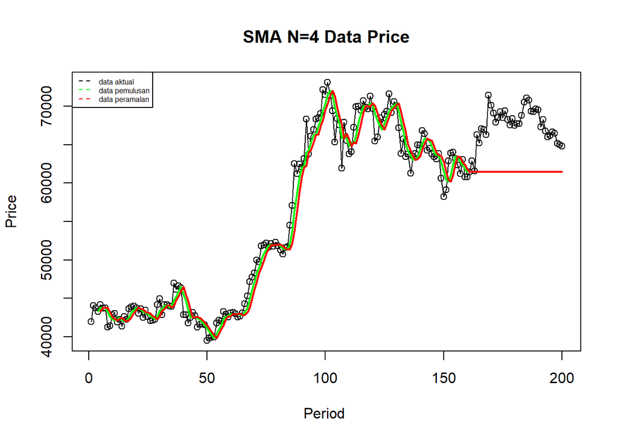

```r
ts.plot(data1.ts, xlab="Period ", ylab="Price", main= "SMA N=4 Data Price")
points(data1.ts)
lines(data.gab[,2],col="green",lwd=2)
lines(data.gab[,3],col="red",lwd=2)
legend("topleft",c("data aktual","data pemulusan","data peramalan"), lty=8, col=c("black","green","red"), cex=0.5)
```

Selanjutnya perhitungan akurasi dilakukan dengan ukuran akurasi *Sum Squares Error* (SSE), *Mean Square Error* (MSE) dan *Mean Absolute Percentage Error* (MAPE). Perhitungan akurasi dilakukan baik pada data latih maupun pada data uji.

$$SSE = \sum_{t=1}^{n} (y_t -
\hat{y}_t)^2$$

$$MSE = \frac{1}{n} \sum_{t=1}^{n} (y_t -
\hat{y}_t)^2$$

$$MAPE = \frac{1}{n} \sum_{t=1}^{n}
\left|\frac{y_t - \hat{y}_t}{y_t}\right| * 100$$

#### Akurasi Data Latih

```r
#Menghitung nilai keakuratan data latih
error_train.sma = train_ma.ts-data.ramal[1:length(train_ma.ts)]

SSE_train.sma = sum(error_train.sma[5:length(train_ma.ts)]^2)
MSE_train.sma = mean(error_train.sma[5:length(train_ma.ts)]^2)
MAPE_train.sma = mean(abs((error_train.sma[5:length(train_ma.ts)]/train_ma.ts[5:length(train_ma.ts)])*100))

akurasi_train.sma <- matrix(c(SSE_train.sma, MSE_train.sma, MAPE_train.sma))
row.names(akurasi_train.sma)<- c("SSE", "MSE", "MAPE")
colnames(akurasi_train.sma) <- c("Akurasi m = 4")
akurasi_train.sma
```

```
##      Akurasi m = 4
## SSE   7.285494e+08
## MSE   4.670188e+06
## MAPE  2.808106e+00
```

#### Akurasi Data Uji

```r
#Menghitung nilai keakuratan data uji
error_test.sma = test_ma.ts-data.gab[161:180,3]

SSE_test.sma = sum(error_test.sma^2)
MSE_test.sma = mean(error_test.sma^2)
MAPE_test.sma = mean(abs((error_test.sma/test_ma.ts*100)))

akurasi_test.sma <- matrix(c(SSE_test.sma, MSE_test.sma, MAPE_test.sma))
row.names(akurasi_test.sma)<- c("SSE", "MSE", "MAPE")
colnames(akurasi_test.sma) <- c("Akurasi m = 4")
akurasi_test.sma
```

```
##      Akurasi m = 4
## SSE   1.684314e+09
## MSE   4.210784e+07
## MAPE  8.872366e+00
```

Perhitungan akurasi menggunakan data latih menghasilkan nilai MAPE yang kurang dari 10% sehingga nilai akurasi ini dapat dikategorikan sebagai sangat baik.

### Double Moving Average (DMA)

Metode pemulusan Double Moving Average (DMA) pada dasarnya mirip dengan SMA. Namun demikian, metode ini lebih cocok digunakan untuk pola data trend. Proses pemulusan dengan rata rata dalam metode ini dilakukan sebanyak 2 kali.

- **Tahap I:**

$$S_{1,t} = \frac{1}{m} \sum_{i=t-m+1}^{t}
X_i$$

- **Tahap II:**

$$S_{2,t} = \frac{1}{m} \sum_{i=t-m+1}^{t}
S_{1,i}$$

Forecast $h$ langkah ke depan dihitung dengan:

$$F_{2,t,t+h} = A_t + B_t
\,(h)$$

dengan komponen level ($A_t$) dan tren ($B_t$):

$$A_t = 2S_{1,t} - S_{2,t}
\qquad\text{dan}\qquad
B_t = \frac{2}{m-1}\,\big(S_{1,t} - S_{2,t}\big)$$

```r
dma <- SMA(data.sma, n = 4)
At <- 2*data.sma - dma
Bt <- 2/(4-1)*(data.sma - dma)
data.dma<- At+Bt
data.ramal2<- c(NA, data.dma)

t = 1:40
f = c()

for (i in t) {
  f[i] = At[length(At)] + Bt[length(Bt)]*(i)
}

data.gab2 <- cbind(aktual = c(data1.ts),
                   pemulusan1 = c(data.sma,rep(NA,40)),
                   pemulusan2 = c(dma, rep(NA,40)),
                   At = c(At, rep(NA,40)),
                   Bt = c(Bt,rep(NA,40)),
                   ramalan = c(data.ramal2, f[-1]))
data.gab2
```

```
##          aktual pemulusan1 pemulusan2       At            Bt  ramalan
##   [1,] 41980.10         NA         NA       NA            NA       NA
##   [2,] 44080.65         NA         NA       NA            NA       NA
##   [3,] 43746.45         NA         NA       NA            NA       NA
##   [4,] 43292.66   43274.96         NA       NA            NA       NA
##   [5,] 44166.60   43821.59         NA       NA            NA       NA
##   [6,] 43725.98   43732.92         NA       NA            NA       NA
##   [7,] 43779.70   43741.24   43642.68 43839.80    65.7057296       NA
##   [8,] 41243.83   43229.03   43631.20 42826.86  -268.1105137 43905.50
##   [9,] 41450.22   42549.93   43313.28 41786.59  -508.8977854 42558.75
##  [10,] 42890.74   42341.12   42965.33 41716.92  -416.1381833 41277.69
##  [11,] 43023.97   42152.19   42568.07 41736.31  -277.2517900 41300.78
##  [12,] 41929.76   42323.67   42341.73 42305.62   -12.0382487 41459.06
##  [13,] 42240.12   42521.15   42334.53 42707.76   124.4086913 42293.58
##  [14,] 41364.66   42139.63   42284.16 41995.10   -96.3549812 42832.17
```

[output cut: 186 more lines]

Hasil pemulusan menggunakan metode DMA divisualisasikan sebagai berikut

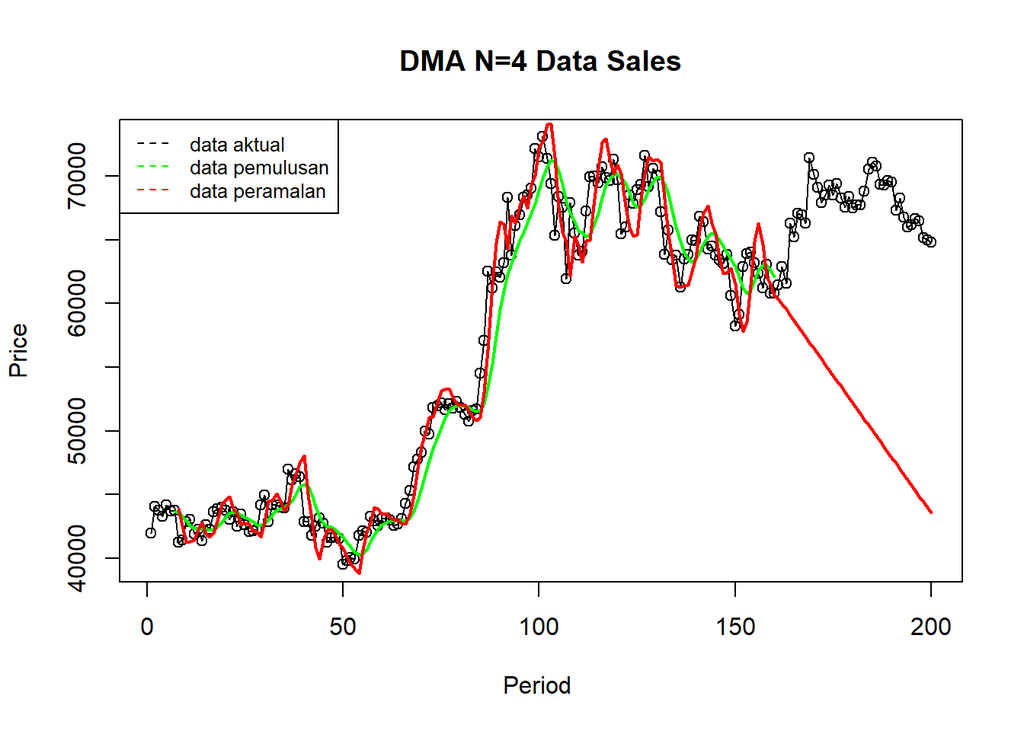

```r
ts.plot(data1.ts, xlab="Period ", ylab="Price", main= "DMA N=4 Data Sales")
points(data1.ts)
lines(data.gab2[,3],col="green",lwd=2)
lines(data.gab2[,6],col="red",lwd=2)
legend("topleft",c("data aktual","data pemulusan","data peramalan"), lty=8, col=c("black","green","red"), cex=0.8)
```

Selanjutnya perhitungan akurasi dilakukan baik pada data latih maupun data uji. Perhitungan akurasi dilakukan dengan ukuran akurasi SSE, MSE dan MAPE.

#### Akurasi Data Latih

```r
#Menghitung nilai keakuratan data latih
error_train.dma = train_ma.ts-data.ramal2[1:length(train_ma.ts)]

SSE_train.dma = sum(error_train.dma[8:length(train_ma.ts)]^2)
MSE_train.dma = mean(error_train.dma[8:length(train_ma.ts)]^2)
MAPE_train.dma = mean(abs((error_train.dma[8:length(train_ma.ts)]/train_ma.ts[8:length(train_ma.ts)])*100))

akurasi_train.dma <- matrix(c(SSE_train.dma, MSE_train.dma, MAPE_train.dma))
row.names(akurasi_train.dma)<- c("SSE", "MSE", "MAPE")
colnames(akurasi_train.dma) <- c("Akurasi m = 4")
akurasi_train.dma
```

```
##      Akurasi m = 4
## SSE   6.890651e+08
## MSE   4.503694e+06
## MAPE  2.801612e+00
```

Perhitungan akurasi pada data latih menggunakan nilai MAPE menghasilkan nilai MAPE yang kurang dari 10% sehingga dikategorikan sangat baik. Selanjutnya, perhitungan nilai akurasi dilakukan pada data uji.

#### Akurasi Data Uji

```r
#Menghitung nilai keakuratan data uji
error_test.dma = test_ma.ts-data.gab2[161:200,6]
SSE_test.dma = sum(error_test.dma^2)
MSE_test.dma = mean(error_test.dma^2)
MAPE_test.dma = mean(abs((error_test.dma/test_ma.ts*100)))

akurasi_test.dma <- matrix(c(SSE_test.dma, MSE_test.dma, MAPE_test.dma))
row.names(akurasi_test.dma)<- c("SSE", "MSE", "MAPE")
colnames(akurasi_test.dma) <- c("Akurasi m = 4")
akurasi_test.dma
```

```
##      Akurasi m = 4
## SSE   1.100867e+10
## MSE   2.752167e+08
## MAPE  2.288641e+01
```

## Exponential Smoothing

Metode Exponential Smoothing merupakan metode pemulusan deret waktu dengan memberikan bobot yang menurun secara eksponensial pada data historis, di mana nilai terbaru mendapat bobot lebih besar dibanding nilai yang lebih lama. Metode ini menggunakan satu atau lebih parameter pemulusan yang secara langsung menentukan besar kecilnya bobot setiap pengamatan. Pemilihan parameter yang tepat akan sangat berpengaruh terhadap hasil ramalan. Secara umum, Exponential Smoothing dibedakan menjadi dua jenis, yaitu model tunggal (single) yang digunakan untuk data tanpa tren maupun musiman, serta model ganda (double) yang mampu menangkap adanya tren pada data.

### Pembagian Data

Pembagian data latih dan data uji dilakukan dengan perbandingan 80% data latih dan 20% data uji.

```r
# jumlah baris data
n <- nrow(data1)

# hitung batas 80%
n_train <- floor(0.8 * n)

# bagi data
training <- data1[1:n_train, ]
testing  <- data1[(n_train+1):n, ]

# ubah ke time series
train.ts <- ts(training$Price)
test.ts  <- ts(testing$Price)
```

### Eksplorasi

Eksplorasi dilakukan dengan membuat plot data deret waktu untuk keseluruhan data, data latih, dan data uji.

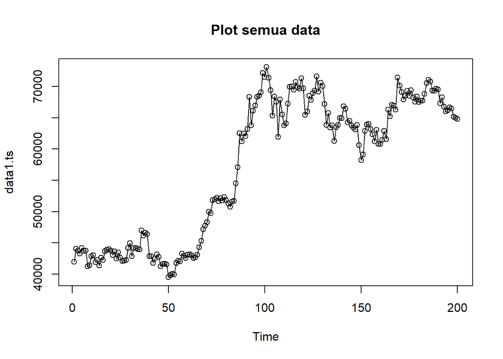

```r
#eksplorasi data
plot(data1.ts, col="black",main="Plot semua data")
points(data1.ts)
```

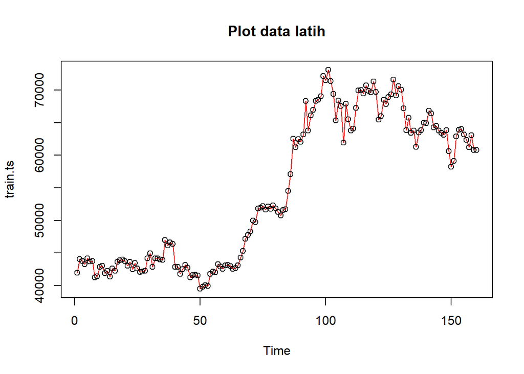

```r
plot(train.ts, col="red",main="Plot data latih")
points(train.ts)
```

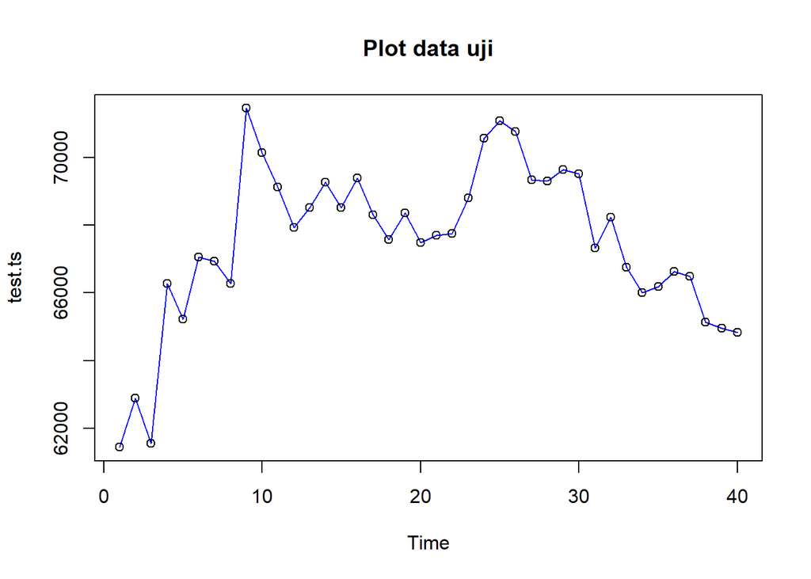

```r
plot(test.ts, col="blue",main="Plot data uji")
points(test.ts)
```

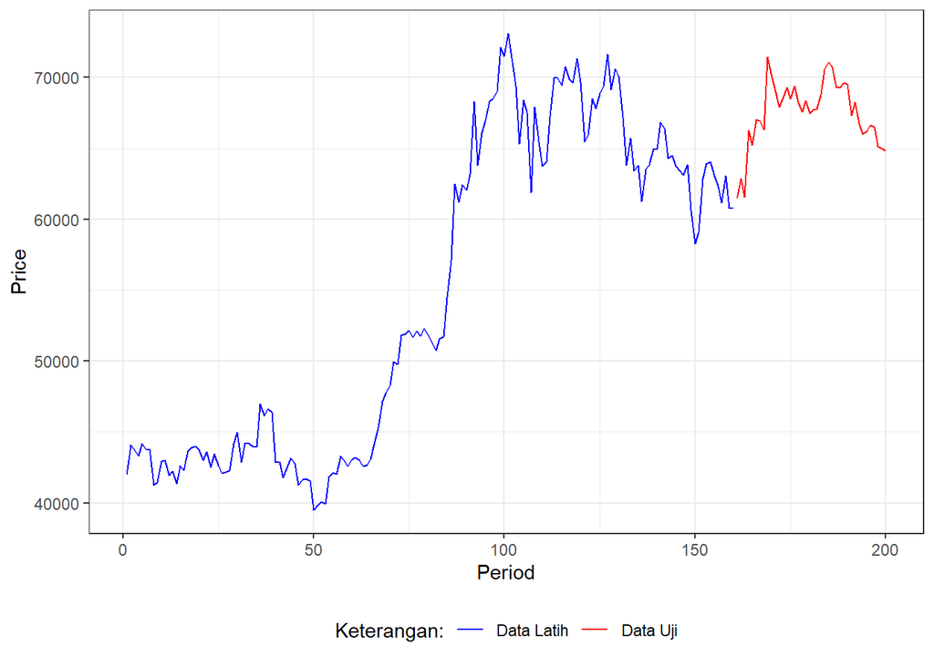

```r
#Eksplorasi dengan GGPLOT
library(ggplot2)
ggplot() +
  geom_line(data = training, aes(x = Period, y = Price, col = "Data Latih")) +
  geom_line(data = testing, aes(x = Period, y = Price, col = "Data Uji")) +
  labs(x = "Period", y = "Price", color = "Legend") +
  scale_colour_manual(name="Keterangan:", breaks = c("Data Latih", "Data Uji"),
                      values = c("blue", "red")) +
  theme_bw() + theme(legend.position = "bottom",
                     plot.caption = element_text(hjust=0.5, size=12))
```

### Single Exponential Smoothing

Single Exponential Smoothing (SES) adalah metode peramalan deret waktu yang dikembangkan untuk mengatasi kelemahan Moving Average. Jika pada Moving Average setiap data periode sebelumnya dianggap memiliki bobot yang sama, maka SES memberikan bobot yang semakin mengecil secara eksponensial terhadap data lama, sehingga data terbaru diberi bobot lebih besar.

Single Exponential Smoothing merupakan metode pemulusan yang tepat digunakan untuk data dengan pola stasioner atau konstan.

Nilai pemulusan pada periode ke-t didapat dari persamaan:

$$\tilde{y}_T=\lambda
y_t+(1-\lambda)\tilde{y}_{T-1}$$

Nilai parameter $\lambda$ adalah nilai antara 0 dan 1.

Nilai pemulusan periode ke-t bertindak sebagai nilai ramalan pada periode ke-$(T+\tau)$.

$$\tilde{y}_{T+\tau}(T)=\tilde{y}_T$$

Pemulusan dengan metode SES dapat dilakukan dengan dua fungsi dari *packages* berbeda, yaitu (1) fungsi `ses()` dari *packages* `forecast` dan (2) fungsi `HoltWinters` dari *packages* `stats` .

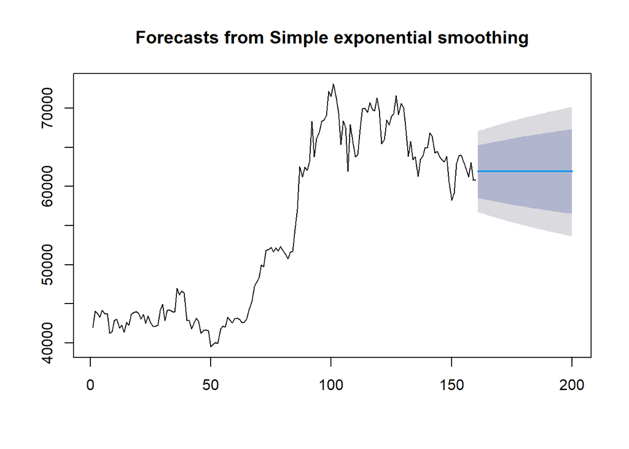

```r
#Cara 1 (fungsi ses)
ses.1 <- ses(train.ts, h = 40, alpha = 0.2)
plot(ses.1)
```

```r
ses.1
```

```
##     Point Forecast    Lo 80    Hi 80    Lo 95    Hi 95
## 161       61903.22 58523.66 65282.79 56734.63 67071.82
## 162       61903.22 58456.73 65349.72 56632.27 67174.18
## 163       61903.22 58391.08 65415.37 56531.86 67274.59
## 164       61903.22 58326.63 65479.82 56433.30 67373.15
## 165       61903.22 58263.32 65543.12 56336.48 67469.97
## 166       61903.22 58201.10 65605.35 56241.31 67565.14
## 167       61903.22 58139.90 65666.55 56147.72 67658.73
## 168       61903.22 58079.69 65726.76 56055.63 67750.82
## 169       61903.22 58020.40 65786.05 55964.96 67841.49
## 170       61903.22 57962.01 65844.44 55875.66 67930.79
## 171       61903.22 57904.47 65901.98 55787.66 68018.79
## 172       61903.22 57847.75 65958.70 55700.91 68105.54
## 173       61903.22 57791.81 66014.64 55615.36 68191.09
## 174       61903.22 57736.62 66069.83 55530.95 68275.50
```

[output cut: 26 more lines]

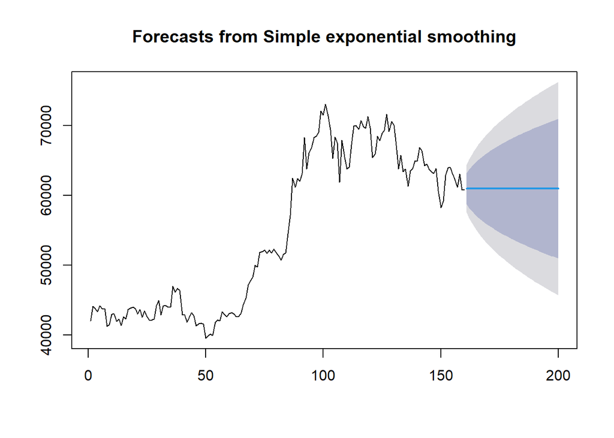

```r
ses.2<- ses(train.ts, h = 40, alpha = 0.7)
plot(ses.2)
```

```r
ses.2
```

```
##     Point Forecast    Lo 80    Hi 80    Lo 95    Hi 95
## 161       60958.07 58727.12 63189.01 57546.13 64370.00
## 162       60958.07 58234.85 63681.28 56793.27 65122.86
## 163       60958.07 57818.85 64097.28 56157.05 65759.08
## 164       60958.07 57451.86 64464.27 55595.79 66320.34
## 165       60958.07 57119.81 64796.33 55087.95 66828.18
## 166       60958.07 56814.27 65101.86 54620.68 67295.45
## 167       60958.07 56529.77 65386.36 54185.57 67730.56
## 168       60958.07 56262.47 65653.66 53776.78 68139.36
## 169       60958.07 56009.59 65906.54 53390.03 68526.10
## 170       60958.07 55769.02 66147.11 53022.11 68894.02
## 171       60958.07 55539.12 66377.01 52670.51 69245.63
## 172       60958.07 55318.59 66597.55 52333.23 69582.91
## 173       60958.07 55106.36 66809.78 52008.65 69907.49
## 174       60958.07 54901.56 67014.58 51695.43 70220.70
```

[output cut: 26 more lines]

Pada fungsi `ses()` , terdapat beberapa argumen yang umum digunakan, yaitu

- `y` : nilai data deret waktu
- `alpha` : parameter pemulusan utama (0–1), mengatur bobot data terbaru vs data lama.
- `beta` : parameter pemulusan tren.
- `gamma` : parameter pemulusan musiman.
- `h` : jumlah periode ke depan yang ingin diramalkan (forecast horizon).

Untuk mendapatkan gambar hasil pemulusan pada data latih dengan fungsi `ses()` , perlu digunakan fungsi `autoplot()` dan `autolayer()` dari *library packages* `ggplot2` .

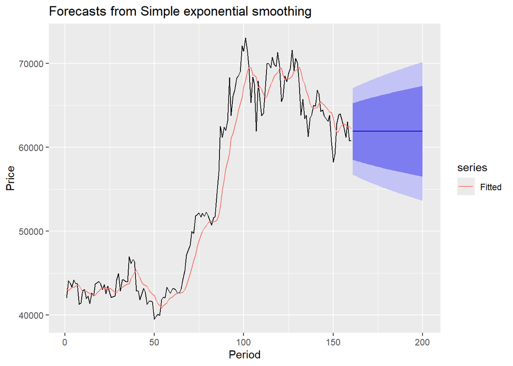

```r
autoplot(ses.1) +
  autolayer(fitted(ses.1), series="Fitted") +
  ylab("Price") + xlab("Period")
```

Selanjutnya akan digunakan fungsi `HoltWinters()` dengan nilai inisialisasi parameter dan panjang periode peramalan yang sama dengan fungsi `ses()` .

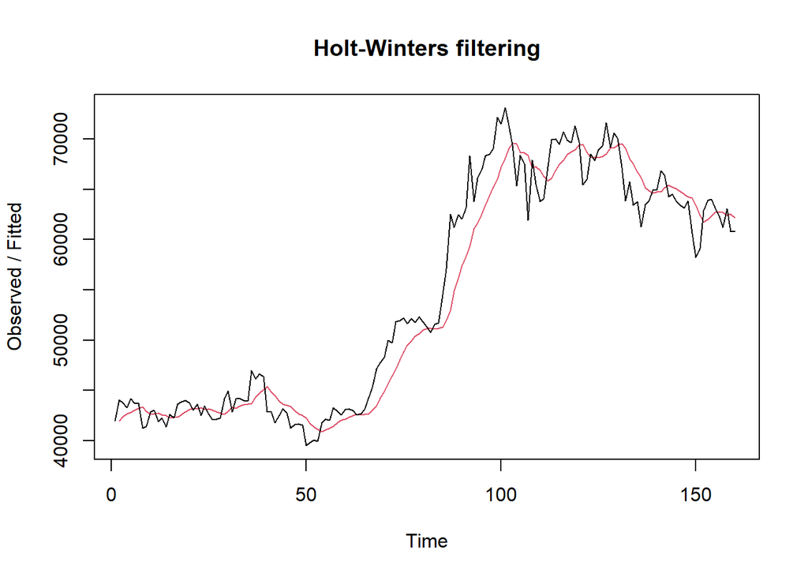

```r
#Cara 2 (fungsi Holtwinter)
ses1<- HoltWinters(train.ts, gamma = FALSE, beta = FALSE, alpha = 0.2)
plot(ses1)
```

```r
#ramalan
ramalan1<- forecast(ses1, h=40)
ramalan1
```

```
##     Point Forecast    Lo 80    Hi 80    Lo 95    Hi 95
## 161       61903.22 58615.44 65191.01 56874.99 66931.46
## 162       61903.22 58550.32 65256.12 56775.41 67031.04
## 163       61903.22 58486.45 65319.99 56677.73 67128.72
## 164       61903.22 58423.76 65382.69 56581.84 67224.61
## 165       61903.22 58362.17 65444.28 56487.65 67318.80
## 166       61903.22 58301.63 65504.82 56395.06 67411.38
## 167       61903.22 58242.10 65564.35 56304.01 67502.43
## 168       61903.22 58183.52 65622.93 56214.42 67592.03
## 169       61903.22 58125.84 65680.61 56126.22 67680.23
## 170       61903.22 58069.04 65737.41 56039.34 67767.11
## 171       61903.22 58013.06 65793.39 55953.73 67852.72
## 172       61903.22 57957.88 65848.57 55869.34 67937.11
## 173       61903.22 57903.46 65902.99 55786.11 68020.34
## 174       61903.22 57849.77 65956.68 55704.00 68102.45
```

[output cut: 26 more lines]

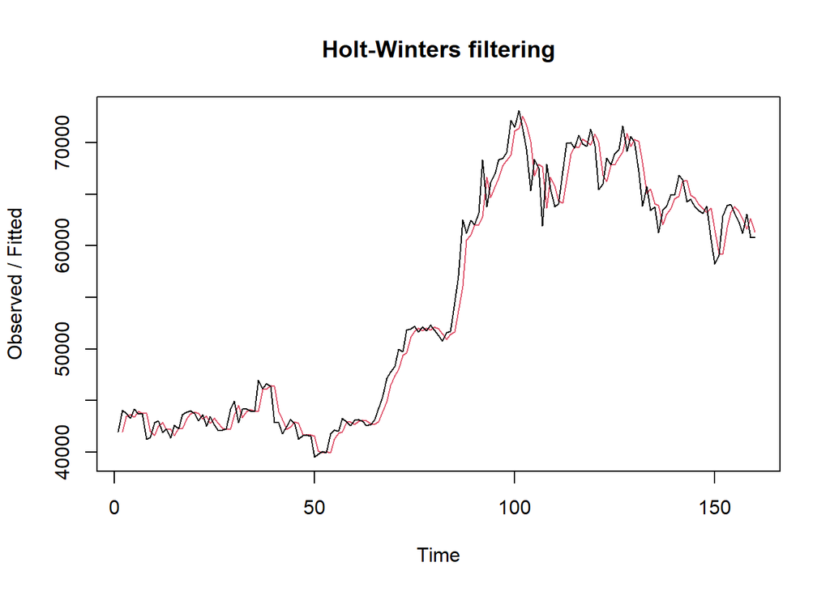

```r
ses2<- HoltWinters(train.ts, gamma = FALSE, beta = FALSE, alpha = 0.7)
plot(ses2)
```

```r
#ramalan
ramalan2<- forecast(ses2, h=40)
ramalan2
```

```
##     Point Forecast    Lo 80    Hi 80    Lo 95    Hi 95
## 161       60958.07 58737.01 63179.12 57561.26 64354.87
## 162       60958.07 58246.93 63669.21 56811.73 65104.40
## 163       60958.07 57832.77 64083.37 56178.33 65737.80
## 164       60958.07 57467.41 64448.73 55619.56 66296.57
## 165       60958.07 57136.82 64779.31 55113.98 66802.16
## 166       60958.07 56832.64 65083.49 54648.78 67267.36
## 167       60958.07 56549.40 65366.73 54215.59 67700.54
## 168       60958.07 56283.29 65632.84 53808.61 68107.52
## 169       60958.07 56031.53 65884.60 53423.58 68492.55
## 170       60958.07 55792.03 66124.11 53057.29 68858.84
## 171       60958.07 55563.15 66352.99 52707.25 69208.89
## 172       60958.07 55343.59 66572.55 52371.46 69544.67
## 173       60958.07 55132.30 66783.84 52048.32 69867.81
## 174       60958.07 54928.41 66987.73 51736.50 70179.63
```

[output cut: 26 more lines]

Fungsi `HoltWinters` memiliki argumen yang sama dengan fungsi `ses()` . Argumen-argumen kedua fungsi dapat dilihat lebih lanjut dengan `?ses()` atau `?HoltWinters` .

Nilai parameter $\alpha$ dari kedua fungsi dapat dioptimalkan menyesuaikan dari *error*-nya paling minimumnya. Caranya adalah dengan membuat parameter $\alpha =$ `NULL` .

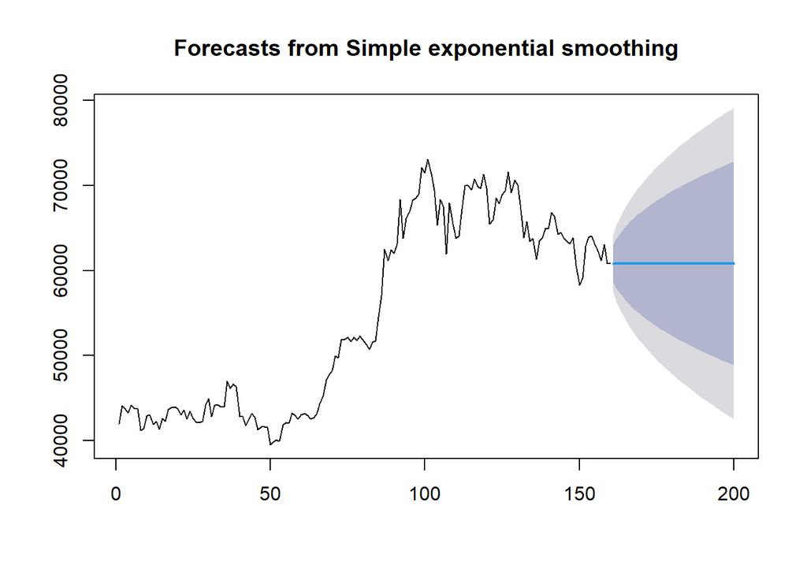

```r
#SES
ses.opt <- ses(train.ts, h = 40, alpha = NULL)
plot(ses.opt)
```

```r
ses.opt
```

```
##     Point Forecast    Lo 80    Hi 80    Lo 95    Hi 95
## 161       60835.56 58636.20 63034.92 57471.92 64199.19
## 162       60835.56 57940.94 63730.17 56408.63 65262.49
## 163       60835.56 57382.96 64288.15 55555.27 66115.84
## 164       60835.56 56903.38 64767.73 54821.81 66849.30
## 165       60835.56 56476.24 65194.87 54168.56 67502.55
## 166       60835.56 56087.38 65583.74 53573.84 68097.27
## 167       60835.56 55728.03 65943.08 53024.27 68646.85
## 168       60835.56 55392.36 66278.76 52510.90 69160.22
## 169       60835.56 55076.21 66594.90 52027.40 69643.71
## 170       60835.56 54776.54 66894.57 51569.09 70102.02
## 171       60835.56 54491.01 67180.10 51132.41 70538.70
## 172       60835.56 54217.79 67453.33 50714.55 70956.56
## 173       60835.56 53955.41 67715.71 50313.27 71357.84
## 174       60835.56 53702.67 67968.44 49926.75 71744.37
```

[output cut: 26 more lines]

```r
#Lamda Optimum Holt Winter
HWopt<- HoltWinters(train.ts, gamma = FALSE, beta = FALSE,alpha = NULL)
HWopt
```

```
## Holt-Winters exponential smoothing without trend and without seasonal component.
##
## Call:
## HoltWinters(x = train.ts, alpha = NULL, beta = FALSE, gamma = FALSE)
##
## Smoothing parameters:
##  alpha: 0.8568689
##  beta : FALSE
##  gamma: FALSE
##
## Coefficients:
##      [,1]
## a 60834.9
```

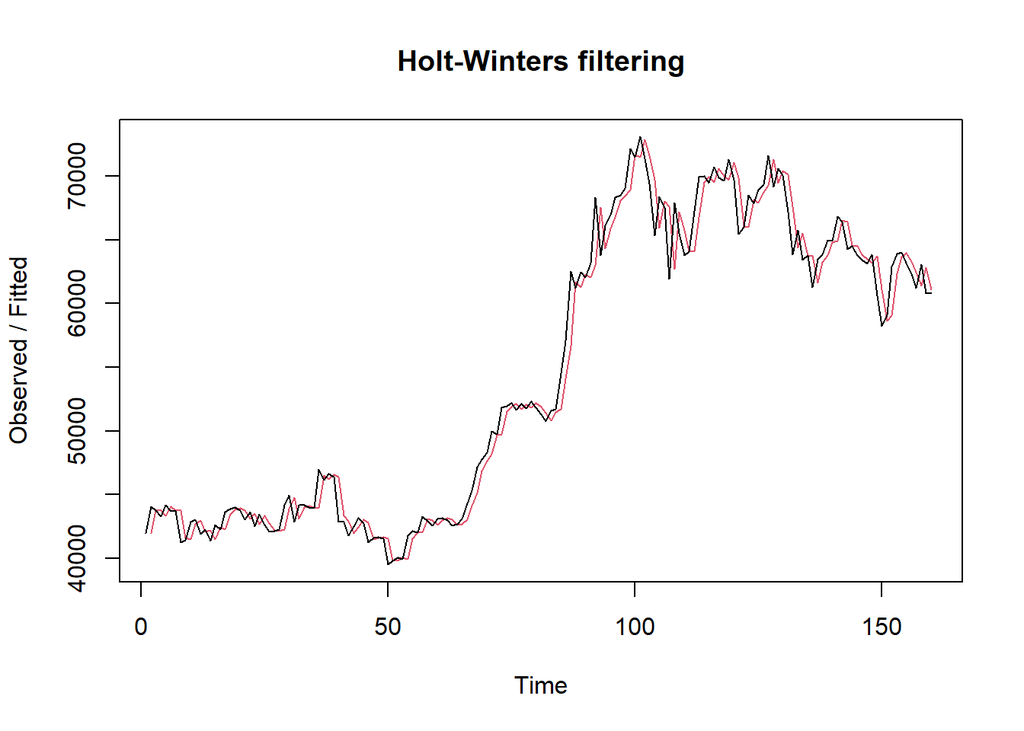

```r
plot(HWopt)
```

```r
#ramalan
ramalanopt<- forecast(HWopt, h=40)
ramalanopt
```

```
##     Point Forecast    Lo 80    Hi 80    Lo 95    Hi 95
## 161        60834.9 58642.53 63027.26 57481.97 64187.83
## 162        60834.9 57947.78 63722.02 56419.43 65250.37
## 163        60834.9 57390.41 64279.38 55567.01 66102.78
## 164        60834.9 56911.44 64758.35 54834.49 66835.30
## 165        60834.9 56484.89 65184.90 54182.14 67487.65
## 166        60834.9 56096.59 65573.20 53588.28 68081.51
## 167        60834.9 55737.79 65932.01 53039.54 68630.26
## 168        60834.9 55402.63 66267.17 52526.96 69142.84
## 169        60834.9 55086.98 66582.82 52044.21 69625.58
## 170        60834.9 54787.78 66882.01 51586.63 70083.16
## 171        60834.9 54502.71 67167.09 51150.65 70519.14
## 172        60834.9 54229.93 67439.87 50733.47 70936.33
## 173        60834.9 53967.97 67701.82 50332.84 71336.95
## 174        60834.9 53715.65 67954.14 49946.95 71722.84
```

[output cut: 26 more lines]

Setelah dilakukan peramalan, akan dilakukan perhitungan keakuratan hasil peramalan. Perhitungan akurasi ini dilakukan baik pada data latih dan data uji.

#### Akurasi Data Latih

Perhitungan akurasi data dapat dilakukan dengan cara langsung maupun manual. Secara langsung, nilai akurasi dapat diambil dari objek yang tersimpan pada hasil SES, yaitu *sum of squared errors* (SSE). Nilai akurasi lain dapat dihitung pula dari nilai SSE tersebut.

```r
#Keakuratan Metode
#Pada data training

# SES dengan alpha = 0.2
SSE1<-ses1$SSE
MSE1<-ses1$SSE/length(train.ts)
RMSE1<-sqrt(MSE1)

akurasi1 <- matrix(c(SSE1,MSE1,RMSE1))
row.names(akurasi1)<- c("SSE", "MSE", "RMSE")
colnames(akurasi1) <- c("Akurasi lamda=0.2")
akurasi1
```

```
##      Akurasi lamda=0.2
## SSE       1.102313e+09
## MSE       6.889458e+06
## RMSE      2.624778e+03
```

```r
# SES dengan alpha = 0.7
SSE2<-ses2$SSE
MSE2<-ses2$SSE/length(train.ts)
RMSE2<-sqrt(MSE2)

akurasi2 <- matrix(c(SSE2,MSE2,RMSE2))
row.names(akurasi2)<- c("SSE", "MSE", "RMSE")
colnames(akurasi2) <- c("Akurasi lamda=0.7")
akurasi2
```

```
##      Akurasi lamda=0.7
## SSE       4.791958e+08
## MSE       2.994973e+06
## RMSE      1.730599e+03
```

```r
#Cara Manual
# Alpha = 0.2
fitted1<-ramalan1$fitted
sisaan1<-ramalan1$residuals
head(sisaan1)
```

```
## Time Series:
## Start = 1
## End = 6
## Frequency = 1
## [1]        NA 2100.5508 1346.2375  623.2087 1372.5045  657.3864
```

```r
resid1<-training$Price-ramalan1$fitted
head(resid1)
```

```
## Time Series:
## Start = 1
## End = 6
## Frequency = 1
## [1]        NA 2100.5508 1346.2375  623.2087 1372.5045  657.3864
```

```r
SSE.1=sum(sisaan1[2:length(train.ts)]^2)
SSE.1
```

```
## [1] 1102313327
```

```r
MSE.1 = SSE.1/length(train.ts)
MSE.1
```

```
## [1] 6889458
```

```r
MAPE.1 = sum(abs(sisaan1[2:length(train.ts)]/train.ts[2:length(train.ts)])*
               100)/length(train.ts)
MAPE.1
```

```
## [1] 3.49017
```

```r
akurasi.1 <- matrix(c(SSE.1,MSE.1,MAPE.1))
row.names(akurasi.1)<- c("SSE", "MSE", "MAPE")
colnames(akurasi.1) <- c("Akurasi lamda=0.2")
akurasi.1
```

```
##      Akurasi lamda=0.2
## SSE       1.102313e+09
## MSE       6.889458e+06
## MAPE      3.490170e+00
```

```r
# Alpha = 0.7
fitted2<-ramalan2$fitted
sisaan2<-ramalan2$residuals
head(sisaan2)
```

```
## Time Series:
## Start = 1
## End = 6
## Frequency = 1
## [1]        NA 2100.5508  295.9621 -364.9926  764.4397 -211.2853
```

```r
resid2<-training$Price-ramalan2$fitted
head(resid2)
```

```
## Time Series:
## Start = 1
## End = 6
## Frequency = 1
## [1]        NA 2100.5508  295.9621 -364.9926  764.4397 -211.2853
```

```r
SSE.2=sum(sisaan2[2:length(train.ts)]^2)
SSE.2
```

```
## [1] 479195757
```

```r
MSE.2 = SSE.2/length(train.ts)
MSE.2
```

```
## [1] 2994973
```

```r
MAPE.2 = sum(abs(sisaan2[2:length(train.ts)]/train.ts[2:length(train.ts)])*
               100)/length(train.ts)
MAPE.2
```

```
## [1] 2.150493
```

```r
akurasi.2 <- matrix(c(SSE.2,MSE.2,MAPE.2))
row.names(akurasi.2)<- c("SSE", "MSE", "MAPE")
colnames(akurasi.2) <- c("Akurasi lamda=0.7")
akurasi.2
```

```
##      Akurasi lamda=0.7
## SSE       4.791958e+08
## MSE       2.994973e+06
## MAPE      2.150493e+00
```

#### Akurasi Data Uji

Akurasi data uji dapat dihitung dengan cara yang hampir sama dengan perhitungan akurasi data latih.

```r
# jumlah observasi uji
n_test <- nrow(testing)

# error (ramalan - aktual), samakan panjang dan tipe numeric
e1   <- as.numeric(ramalan1$mean)[1:n_test] - as.numeric(testing$Price)
e2   <- as.numeric(ramalan2$mean)[1:n_test] - as.numeric(testing$Price)
eopt <- as.numeric(ramalanopt$mean)[1:n_test] - as.numeric(testing$Price)

# SSE / MSE / RMSE untuk masing-masing model (abaikan NA)
SSEtesting1  <- sum(e1^2,  na.rm = TRUE)
MSEtesting1  <- mean(e1^2, na.rm = TRUE)
RMSEtesting1 <- sqrt(MSEtesting1)

SSEtesting2  <- sum(e2^2,  na.rm = TRUE)
MSEtesting2  <- mean(e2^2, na.rm = TRUE)
RMSEtesting2 <- sqrt(MSEtesting2)

SSEtestingopt  <- sum(eopt^2,  na.rm = TRUE)
MSEtestingopt  <- mean(eopt^2, na.rm = TRUE)
RMSEtestingopt <- sqrt(MSEtestingopt)

# Tabel ringkas
akurasitesting_SSE <- matrix(c(SSEtesting1, SSEtesting2, SSEtestingopt),
                             nrow = 3,
                             dimnames = list(c("SSE1","SSE2","SSEopt"), "Nilai"))
akurasitesting_MSE <- matrix(c(MSEtesting1, MSEtesting2, MSEtestingopt),
                             nrow = 3,
                             dimnames = list(c("MSE1","MSE2","MSEopt"), "Nilai"))
akurasitesting_RMSE <- matrix(c(RMSEtesting1, RMSEtesting2, RMSEtestingopt),
                              nrow = 3,
                              dimnames = list(c("RMSE1","RMSE2","RMSEopt"), "Nilai"))

akurasitesting_SSE
```

```
##             Nilai
## SSE1   1475390083
## SSE2   1935851127
## SSEopt 2001119930
```

```r
akurasitesting_MSE
```

```
##           Nilai
## MSE1   36884752
## MSE2   48396278
## MSEopt 50027998
```

```r
akurasitesting_RMSE
```

```
##            Nilai
## RMSE1   6073.282
## RMSE2   6956.743
## RMSEopt 7073.047
```

Selain dengan cara di atas, perhitungan nilai akurasi dapat menggunakan fungsi `accuracy()` dari *package* `forecast` . Penggunaannya yaitu dengan menuliskan `accuracy(hasil ramalan, kondisi aktual)` . Contohnya adalah sebagai berikut.

```r
accuracy(ramalan1, testing$Price)
```

```
##                     ME     RMSE     MAE      MPE     MAPE     MASE      ACF1
## Training set  626.5134 2633.019 1974.95 1.033380 3.512121 1.612526 0.7400637
## Test set     5617.1567 6073.282 5657.42 8.208732 8.274207 4.619224        NA
```

```r
accuracy(ramalan2, testing$Price)
```

```
##                     ME     RMSE      MAE       MPE     MAPE      MASE      ACF1
## Training set  170.5118 1736.033 1222.551 0.2774227 2.164018 0.9981998 0.1553034
## Test set     6562.3148 6956.743 6562.315 9.6102298 9.610230 5.3580610        NA
```

```r
accuracy(ramalanopt, testing$Price)
```

```
##                     ME     RMSE      MAE       MPE     MAPE      MASE
## Training set  138.3918 1710.928 1194.904 0.2233888 2.109814 0.9756267
## Test set     6685.4840 7073.047 6685.484 9.7928673 9.792867 5.4586273
##                      ACF1
## Training set -0.009652322
## Test set               NA
```

### *Double Exponential Smoothing* (DES)

Metode pemulusan *Double Exponential Smoothing* (DES) digunakan untuk data yang memiliki pola tren. Metode DES adalah metode semacam SES, hanya saja dilakukan dua kali, yaitu pertama untuk tahapan ‘level’ dan kedua untuk tahapan ‘tren’. Pemulusan menggunakan metode ini akan menghasilkan peramalan tidak konstan untuk periode berikutnya.

Pemulusan dengan metode DES kali ini akan menggunakan fungsi `HoltWinters()` . Jika sebelumnya nilai argumen `beta` dibuat `FALSE` , kali ini argumen tersebut akan diinisialisasi bersamaan dengan nilai `alpha` .

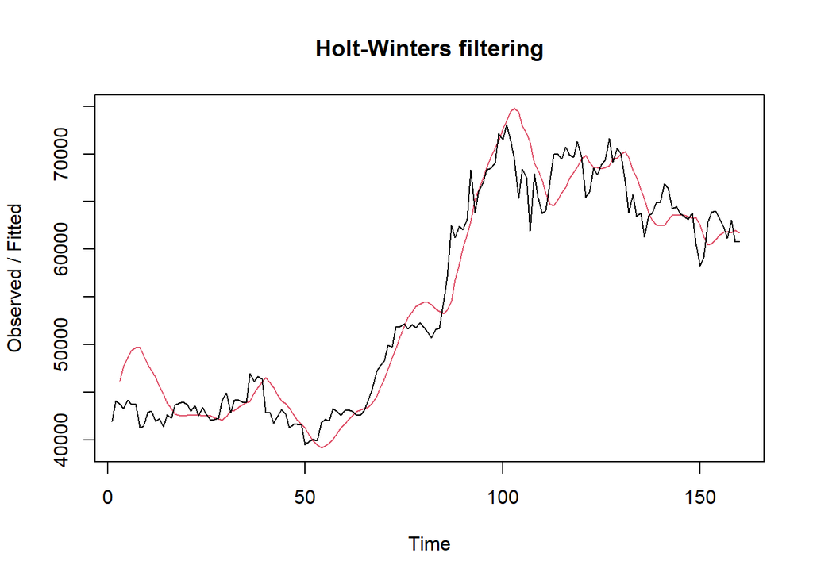

```r
#Lamda=0.2 dan gamma=0.2
des.1<- HoltWinters(train.ts, gamma = FALSE, beta = 0.2, alpha = 0.2)
plot(des.1)
```

```r
#ramalan
ramalandes1<- forecast(des.1, h=40)
ramalandes1
```

```
##     Point Forecast    Lo 80    Hi 80    Lo 95    Hi 95
## 161       61445.16 57768.63 65121.68 55822.40 67067.91
## 162       61369.58 57588.66 65150.50 55587.16 67152.00
## 163       61294.01 57375.45 65212.56 55301.09 67286.92
## 164       61218.43 57127.07 65309.79 54961.24 67475.62
## 165       61142.86 56842.74 65442.97 54566.40 67719.32
## 166       61067.28 56522.65 65611.91 54116.87 68017.70
## 167       60991.71 56167.75 65815.66 53614.10 68369.31
## 168       60916.13 55779.52 66052.75 53060.36 68771.91
## 169       60840.56 55359.70 66321.41 52458.31 69222.80
## 170       60764.98 54910.19 66619.78 51810.84 69719.12
## 171       60689.41 54432.84 66945.98 51120.81 70258.01
## 172       60613.83 53929.43 67298.23 50390.93 70836.73
## 173       60538.26 53401.64 67674.88 49623.74 71452.77
## 174       60462.68 52850.95 68074.41 48821.54 72103.82
```

[output cut: 26 more lines]

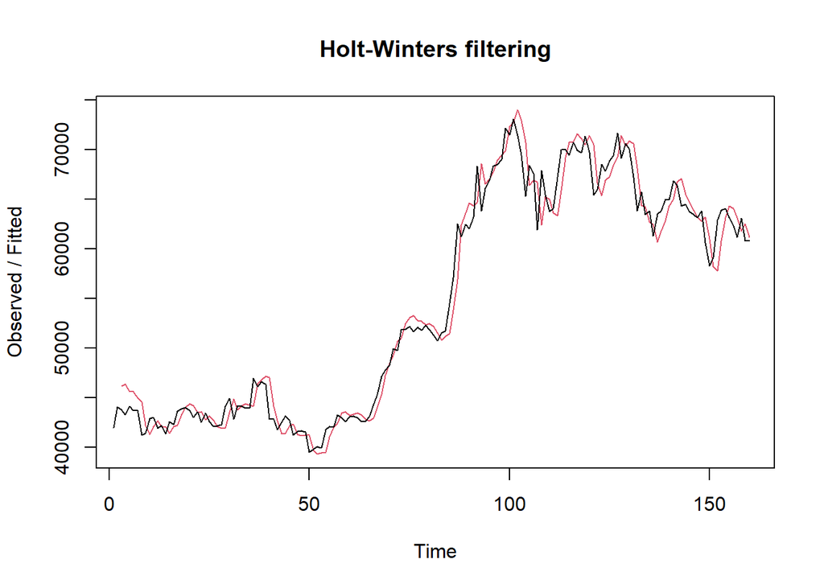

```r
#Lamda=0.6 dan gamma=0.3
des.2<- HoltWinters(train.ts, gamma = FALSE, beta = 0.3, alpha = 0.6)
plot(des.2)
```

```r
#ramalanh
ramalandes2<- forecast(des.2, h=40)
ramalandes2
```

```
##     Point Forecast       Lo 80     Hi 80      Lo 95     Hi 95
## 161       60575.36  58149.4835  63001.23  56865.303  64285.42
## 162       60199.56  57123.0022  63276.12  55494.369  64904.76
## 163       59823.77  55965.1763  63682.36  53922.562  65724.97
## 164       59447.97  54700.6877  64195.26  52187.627  66708.32
## 165       59072.18  53345.8765  64798.48  50314.557  67829.80
## 166       58696.38  51911.7308  65481.03  48320.154  69072.61
## 167       58320.58  50405.9822  66235.19  46216.245  70424.92
## 168       57944.79  48834.3424  67055.23  44011.564  71878.01
## 169       57568.99  47201.2201  67936.77  41712.853  73425.13
## 170       57193.20  45510.1447  68876.25  39325.510  75060.88
## 171       56817.40  43764.0273  69870.78  36853.988  76780.81
## 172       56441.61  41965.3272  70917.88  34302.048  78581.16
## 173       56065.81  40116.1630  72015.46  31672.930  80458.69
## 174       55690.01  38218.3882  73161.64  28969.468  82410.56
```

[output cut: 26 more lines]

Selanjutnya jika ingin membandingkan plot data latih dan data uji adalah sebagai berikut.

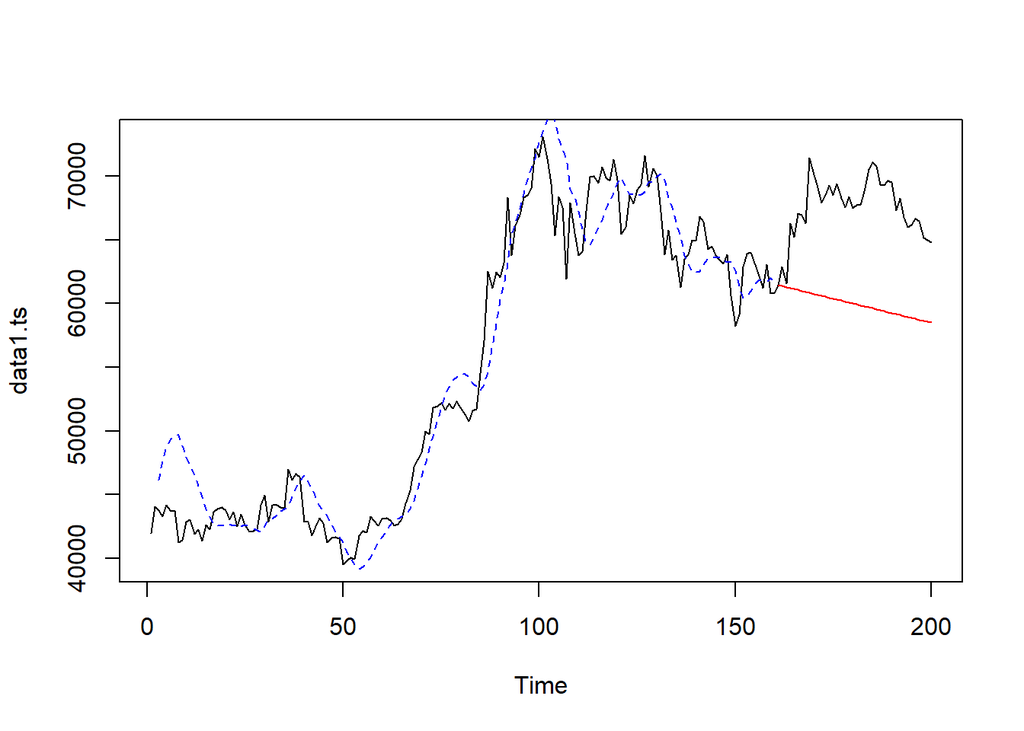

```r
plot(data1.ts)
lines(des.1$fitted[,1], lty=2, col="blue")
lines(ramalandes1$mean, col="red")
```

Untuk mendapatkan nilai parameter optimum dari DES, argumen `alpha` dan `beta` dapat dibuat `NULL` seperti berikut.

```r
#Lamda dan gamma optimum
des.opt<- HoltWinters(train.ts, gamma = FALSE)
des.opt
```

```
## Holt-Winters exponential smoothing with trend and without seasonal component.
##
## Call:
## HoltWinters(x = train.ts, gamma = FALSE)
##
## Smoothing parameters:
##  alpha: 0.8624192
##  beta : 0.1075095
##  gamma: FALSE
##
## Coefficients:
##         [,1]
## a 60802.4494
## b  -212.7417
```

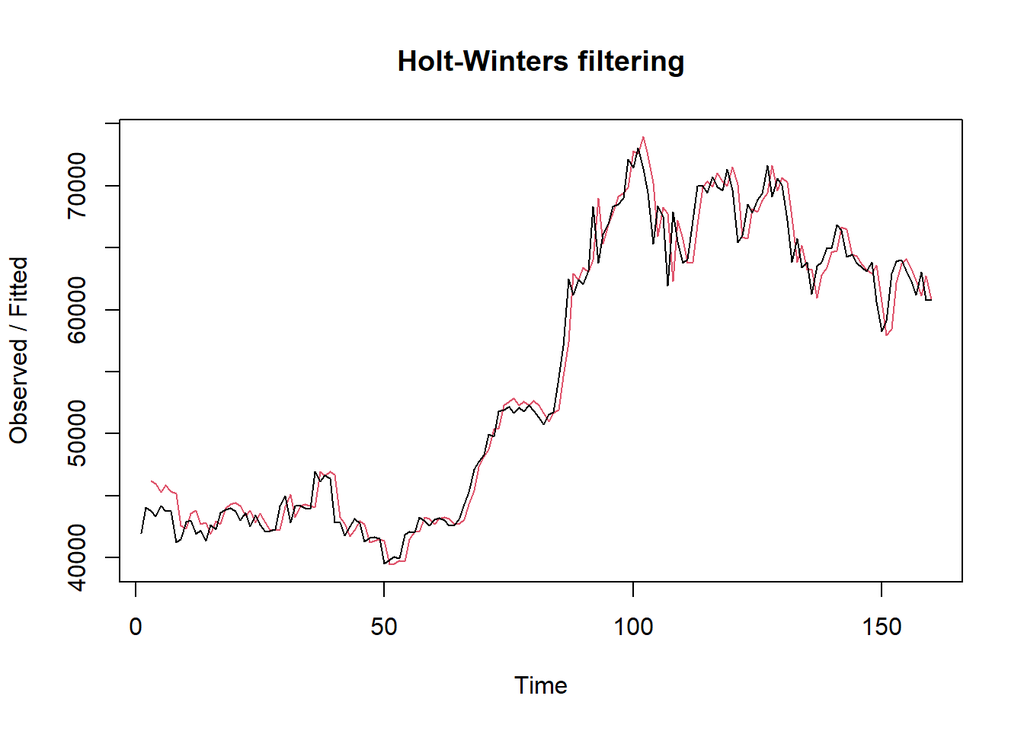

```r
plot(des.opt)
```

```r
#ramalan
ramalandesopt<- forecast(des.opt, h=40)
ramalandesopt
```

```
##     Point Forecast    Lo 80    Hi 80       Lo 95     Hi 95
## 161       60589.71 58284.06 62895.36  57063.5200  64115.90
## 162       60376.97 57188.59 63565.35  55500.7602  65253.17
## 163       60164.22 56163.88 64164.57  54046.2234  66282.23
## 164       59951.48 55164.16 64738.80  52629.9093  67273.06
## 165       59738.74 54170.60 65306.88  51223.0102  68254.47
## 166       59526.00 53173.73 65878.27  49811.0408  69240.96
## 167       59313.26 52168.23 66458.28  48385.8855  70240.63
## 168       59100.52 51150.94 67050.09  46942.6961  71258.34
## 169       58887.77 50119.90 67655.65  45478.4654  72297.08
## 170       58675.03 49073.85 68276.21  43991.2936  73358.77
## 171       58462.29 48012.02 68912.56  42479.9808  74444.60
## 172       58249.55 46933.92 69565.18  40943.7845  75555.31
## 173       58036.81 45839.26 70234.35  39382.2710  76691.34
## 174       57824.07 44727.91 70920.23  37795.2180  77852.91
```

[output cut: 26 more lines]

Selanjutnya akan dilakukan perhitungan akurasi pada data latih maupun data uji dengan ukuran akurasi SSE, MSE dan MAPE.

#### Akurasi Data Latih

```r
#Akurasi Data Training
ssedes.train1<-des.1$SSE
msedes.train1<-ssedes.train1/length(train.ts)
sisaandes1<-ramalandes1$residuals
head(sisaandes1)
```

```
## Time Series:
## Start = 1
## End = 6
## Frequency = 1
## [1]        NA        NA -2434.754 -4404.745 -4476.829 -5669.978
```

```r
mapedes.train1 <- sum(abs(sisaandes1[3:length(train.ts)]/train.ts[3:length(train.ts)])
                      *100)/length(train.ts)

akurasides.1 <- matrix(c(ssedes.train1,msedes.train1,mapedes.train1))
row.names(akurasides.1)<- c("SSE", "MSE", "MAPE")
colnames(akurasides.1) <- c("Akurasi lamda=0.2 dan gamma=0.2")
akurasides.1
```

```
##      Akurasi lamda=0.2 dan gamma=0.2
## SSE                     1.310849e+09
## MSE                     8.192805e+06
## MAPE                    4.027730e+00
```

```r
ssedes.train2<-des.2$SSE
msedes.train2<-ssedes.train2/length(train.ts)
sisaandes2<-ramalandes2$residuals
head(sisaandes2)
```

```
## Time Series:
## Start = 1
## End = 6
## Frequency = 1
## [1]        NA        NA -2434.754 -3089.978 -1468.153 -1869.710
```

```r
mapedes.train2 <- sum(abs(sisaandes2[3:length(train.ts)]/train.ts[3:length(train.ts)])
                      *100)/length(train.ts)

akurasides.2 <- matrix(c(ssedes.train2,msedes.train2,mapedes.train2))
row.names(akurasides.2)<- c("SSE", "MSE", "MAPE")
colnames(akurasides.2) <- c("Akurasi lamda=0.6 dan gamma=0.3")
akurasides.2
```

```
##      Akurasi lamda=0.6 dan gamma=0.3
## SSE                     5.637522e+08
## MSE                     3.523451e+06
## MAPE                    2.473322e+00
```

Hasil akurasi dari data latih didapatkan skenario 2 dengan lamda=0.6 dan gamma=0.3 memiliki hasil yang lebih baik. Namun untuk kedua skenario dapat dikategorikan peramalan sangat baik berdasarkan nilai MAPE-nya.

#### Akurasi Data Uji

```r
#Akurasi Data Testing
selisihdes1<-ramalandes1$mean-testing$Price
selisihdes1
```

```
## Time Series:
## Start = 161
## End = 200
## Frequency = 1
##  [1]     -3.238648  -1531.868323   -258.783147  -5049.061261  -4088.726086
##  [6]  -5984.594040  -5949.098714  -5362.236199 -10607.639303  -9371.550227
## [11]  -8432.929902  -7315.731446  -7987.845490  -8803.264224  -8130.987649
## [16]  -9083.023573  -8060.262617  -7417.712602  -8280.186026  -7482.182880
## [21]  -7773.281305  -7893.520349  -9022.275023 -10860.834388 -11451.464052
## [26] -11201.382786  -9862.379651  -9901.142135 -10318.935869 -10258.799914
## [31]  -8154.124898  -9138.856132  -7729.642057  -7059.912351  -7315.393585
## [36]  -7839.015450  -7765.840434  -6491.864628  -6386.990403  -6330.924757
```

```r
SSEtestingdes1<-sum(selisihdes1^2)
MSEtestingdes1<-SSEtestingdes1/length(testing$Price)
MAPEtestingdes1<-sum(abs(selisihdes1/testing$Price)*100)/length(testing$Price)

selisihdes2<-ramalandes2$mean-testing$Price
selisihdes2
```

```
## Time Series:
## Start = 161
## End = 200
## Frequency = 1
##  [1]   -873.0356  -2701.8861  -1729.0217  -6819.5206  -6159.4062  -8355.4949
##  [7]  -8620.2204  -8333.5786 -13879.2025 -12943.3342 -12304.9347 -11487.9570
## [13] -12460.2918 -13575.9314 -13203.8756 -14456.1323 -13733.5921 -13391.2629
## [19] -14553.9571 -14056.1747 -14647.4939 -15067.9537 -16496.9292 -18635.7093
## [25] -19526.5598 -19576.6993 -18537.9169 -18876.9002 -19594.9147 -19834.9995
## [31] -18030.5453 -19315.4973 -18206.5040 -17836.9951 -18392.6971 -19216.5398
## [37] -19443.5855 -18469.8305 -18665.1771 -18909.3322
```

```r
SSEtestingdes2<-sum(selisihdes2^2)
MSEtestingdes2<-SSEtestingdes2/length(testing$Price)
MAPEtestingdes2<-sum(abs(selisihdes2/testing$Price)*100)/length(testing$Price)

selisihdesopt<-ramalandesopt$mean-testing$Price
selisihdesopt
```

```
## Time Series:
## Start = 161
## End = 200
## Frequency = 1
##  [1]   -858.6868  -2524.4832  -1388.5647  -6316.0095  -5492.8410  -7525.8757
##  [7]  -7627.5471  -7177.8513 -12560.4211 -11461.4987 -10660.0451  -9680.0133
## [13] -10489.2941 -11441.8795 -10906.7696 -11995.9722 -11110.3780 -10604.9947
## [19] -11604.6348 -10943.7983 -11372.0635 -11629.4692 -12895.3906 -14871.1167
## [25] -15598.9130 -15485.9985 -14284.1620 -14460.0912 -15015.0516 -15092.0824
## [31] -13124.5741 -14246.4720 -12974.4246 -12441.8616 -12834.5096 -13495.2981
## [37] -13559.2898 -12422.4807 -12454.7732 -12535.8742
```

```r
SSEtestingdesopt<-sum(selisihdesopt^2)
MSEtestingdesopt<-SSEtestingdesopt/length(testing$Price)
MAPEtestingdesopt<-sum(abs(selisihdesopt/testing$Price)*100)/length(testing$Price)

akurasitestingdes <-
  matrix(c(SSEtestingdes1,MSEtestingdes1,MAPEtestingdes1,SSEtestingdes2,MSEtestingdes2,
           MAPEtestingdes2,SSEtestingdesopt,MSEtestingdesopt,MAPEtestingdesopt),
         nrow=3,ncol=3)
row.names(akurasitestingdes)<- c("SSE", "MSE", "MAPE")
colnames(akurasitestingdes) <- c("des ske1","des ske2","des opt")
akurasitestingdes
```

```
##          des ske1     des ske2      des opt
## SSE  2.547630e+09 9.236306e+09 5.433202e+09
## MSE  6.369075e+07 2.309077e+08 1.358301e+08
## MAPE 1.106553e+01 2.100561e+01 1.628622e+01
```